# Geospatial Analyis Workbook: Using Kriging to grid sparse carbon isotope data in Python

*-- Aidan Starr -- 2023 --*

### The data - Williams et al., 2021

The data in question is a table of hydrographic and carbon system measurements taken at various locations ("Stations") by Thomas J. Williams et al., in the Southeast Indian Ocean. [The original publication can be found here](https://doi.org/10.1029/2020GC009402). The measurements taken include the temperature, salinity, and dissolved oxygen content of seawater as well as the **carbon isotope composition of Dissolved Inorganic Carbon (DIC)**. The carbon isotope composition of DIC (known as $\mathrm{\delta^{13}C_{DIC}}$) refers to the ratio betwen the two most abundant isotopes of carbon: carbon-12 and carbon-13. This is a useful measurement because different sources of carbon dioxide in the atmopshere has distinct 13C-12C ratios, and so we can use it to trace different natural and anthropogenic sources of carbon in the atmosphere and ocean.

## Spatial interpolation

There are several ways of interpolating geospatial data to give a gridded product, spanning a range of complexity. Simple approaches might include linear interpolation between each datapoint, or inverse distance weighting. Alternatively, one can use K-nearest neighbours to classify new data points (i.e. grid points) based on the value or classification of the nearest k neighbouring points. Perhaps more suitable for the oceanographic data I'm using here is a method known as Kriging. Kriging works by modeling the spatial autocorrelation of a dataset, as described by a **variogram**. Various types of Kriging exist - an in depth review of these can be found [here](https://doi.org/10.1016/j.catena.2013.09.006). In this notebook I'll implement 'ordinary' and 'universal' Kriging methods.

### PyKrige

Luckily for me, there's an excellent python module called `pykrige` which has implementations for ordinary and universal Kriging. These functions even allow the user to define different variogram models and model types! In this example I stick to a linear variogram model. The documentation for PyKrige [can be found here](https://geostat-framework.readthedocs.io/projects/pykrige/en/stable/index.html).

```python
import pandas as pd
import numpy as np # numpy for basic computations
import matplotlib as mpl
import matplotlib.pyplot as plt # matplotlib for plotting
import os
os.environ['USE_PYGEOS'] = '0'
import geopandas as gpd # import geopandas to deal with geospatial datasets
plt.style.use('bmh')


mpl.rcParams['font.sans-serif'] = "Arial"
mpl.rcParams['font.family'] = "sans-serif"
```

```python
# url = 'https://www.ncei.noaa.gov/access/metadata/landing-page/bin/iso?id=gov.noaa.nodc:0219887'
df = pd.read_csv('DELTA_CARBON-13__OXYGEN__and_others_collected_from_THOMAS_G._THOMPSON_in_Indian_Ocean_and_Southern_Ocean_from_2018-11-07_to_2018-12-12_V2.csv')

### firstly, convert the pandas dataframe into a GeoPandas dataframe
ctd_df = pd.read_csv('DELTA_CARBON-13__OXYGEN__and_others_collected_from_THOMAS_G._THOMPSON_in_Indian_Ocean_and_Southern_Ocean_from_2018-11-07_to_2018-12-12_V2.csv')
ctd_df = ctd_df.replace(-999,np.nan)
ctd_gdf = gpd.GeoDataFrame(ctd_df, geometry=gpd.points_from_xy(ctd_df.Long_E, ctd_df.Lat))
ctd_gdf = ctd_gdf.set_crs('EPSG:4326')
```

## Plot the station locatons

We can see that the stations are all located in the Southeast Indian Ocean. This will help to inform our choice of Cartesian map projection.

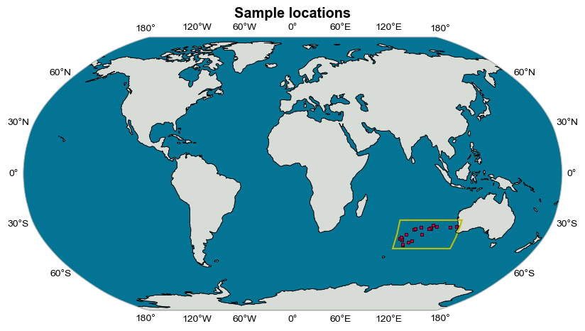

```python
import cartopy.crs as ccrs
import matplotlib.patches as mpatches
import cartopy

min_x, min_y, max_x, max_y = ctd_gdf.total_bounds


fig = plt.figure(figsize=(10, 5))
ax = fig.add_subplot(1, 1, 1, projection=ccrs.Robinson())
ax.set_global()
ax.coastlines()
ax.add_feature(cartopy.feature.OCEAN, zorder=0,color='xkcd:sea blue')
ax.add_feature(cartopy.feature.LAND, zorder=0, facecolor='xkcd:light grey',edgecolor='black')

ax.scatter(ctd_df['Long_E'],ctd_df['Lat'],s=10,facecolor='xkcd:ruby',edgecolor='k',marker='o',transform=ccrs.PlateCarree(),alpha=0.5)
gl = ax.gridlines(draw_labels=True, linewidth=0.5, alpha=0, color='k',linestyle='--')
ax.add_patch(mpatches.Rectangle(xy=[min_x-3, min_y-2], width=(max_x-min_x)+5, height=(max_y-min_y)+5,
                                facecolor='none', edgecolor='y',lw=1.5,
                                transform=ccrs.PlateCarree()))

ax.set_title('Sample locations',fontweight='bold')
```

## First look at the carbon isotope data

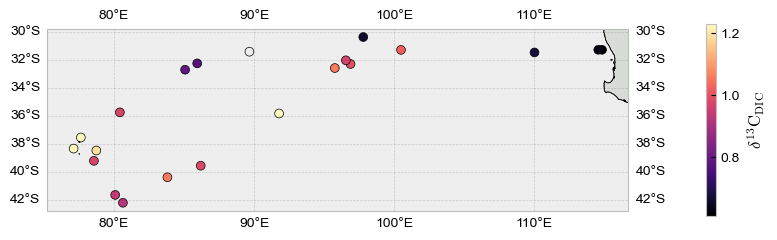

```python
fig = plt.figure(figsize=(10, 5))
ax = fig.add_subplot(1, 1, 1, projection=ccrs.PlateCarree())
ax.coastlines()
# ax.add_feature(cartopy.feature.OCEAN, zorder=0,color='xkcd:sea blue')
ax.add_feature(cartopy.feature.LAND, zorder=0, facecolor='xkcd:light grey',edgecolor='black')


ctd_ = ctd_df[ctd_df['Depth_m']==3]
sc = ax.scatter(ctd_['Long_E'],ctd_['Lat'],c=ctd_['d13C_permil_VPDB'],s=40,edgecolor='k',marker='o',transform=ccrs.PlateCarree(),cmap='magma')
plt.colorbar(sc,shrink=0.5,pad=0.1,label='$\mathrm{\delta^{13}C_{DIC}}$')

gl = ax.gridlines(draw_labels=True,linewidth=0.5, alpha=0.15, color='k',linestyle='--')
```

```python
ctd_gdf.head(3)
```

|  | Cruise | Sample_ID | Long_E | Lat | Date | Station | Deployment | Depth_m | T090C | Sal00 | Density_kg/L | Oygen_ml/L | d13C_permil_VPDB | Nitrate_umol/kg-1 | Phosphate_umol/kg-1 | geometry |
| --- | --- | --- | --- | --- | --- | --- | --- | --- | --- | --- | --- | --- | --- | --- | --- | --- |
| 0 | TT1811 | TT1811-d13C-001 | 114.821522 | -31.29255 | 2018-11-07 17:14 UTC | 1 | 01CTD | 640 | 5.43 | 34.3968 | 1.027146 | 4.83 | 1.01 | 28.4 | 2.3 | POINT (114.82152 -31.29255) |
| 1 | TT1811 | TT1811-d13C-002 | 114.821522 | -31.29255 | 2018-11-07 17:14 UTC | 1 | 01CTD | 500 | 8.57 | 34.6024 | 1.026875 | 5.59 | 1.04 | 17.4 | 1.2 | POINT (114.82152 -31.29255) |
| 2 | TT1811 | TT1811-d13C-003 | 114.821522 | -31.29255 | 2018-11-07 17:14 UTC | 1 | 01CTD | 400 | 10.50 | 34.8425 | 1.026742 | 5.91 | 0.73 | 11.6 | 0.7 | POINT (114.82152 -31.29255) |

## Next steps

The next steps are to prepare the dataset for gridding. To do this, we need to convert the grid from a Lat-Lon projection to a [Cartesian](https://www.ordnancesurvey.co.uk/documents/resources/guide-coordinate-systems-great-britain.pdf) projection. This is because, currently, the station locations are actually given as angles rather than locations on a plane. For gridding, we want to minimise distortion by working in units of *m* or *km* instead of *º latitude and longitude*.

### Which grid to use?

```python
proj = 'EPSG:7078' ## ESPG code for the french southern projection
ctd_gdf=ctd_gdf.to_crs(proj) # convert projection to EPSG7078
ctd_gdf.crs
```

```
<Derived Projected CRS: EPSG:7078>
Name: RGTAAF07 / UTM zone 41S
Axis Info [cartesian]:
- E[east]: Easting (metre)
- N[north]: Northing (metre)
Area of Use:
- name: French Southern Territories - Kerguelen offshore west of 66°E.
- bounds: (62.96, -53.03, 66.0, -45.73)
Coordinate Operation:
- name: UTM zone 41S
- method: Transverse Mercator
Datum: Reseau Geodesique des Terres Australes et Antarctiques Francaises 2007
- Ellipsoid: GRS 1980
- Prime Meridian: Greenwich
```

### Now, let's create a new grid on which to project the gridded data

```python
### --- create new grid --- ###
XX_pk_ = np.linspace(min_x-(min_x*0.05), max_x+(max_x*0.01), 200) # Create a 100 by 100 grid
YY_pk_ = np.linspace(min_y-(min_y*0.05), max_y+(max_y*0.01), 200) # Horizontal and vertical cell counts should be the same
new_grid = [list(xy) for xy in zip(XX_pk_, YY_pk_)] # Create list of XY ctd pairs
```

## Build the Kriging function

Below I define a function to wrap the PyKrige functions in. I provide two option for Universal or Ordinary Kriging, although we could include any number of Variogram models. A more in-depth function might include a step where one defines a variogram model (for example using the `GStats` module) and then provides this variogram directly to PyKrige.

```python
import xarray as xr
import pyproj
from pykrige.ok import OrdinaryKriging
from pykrige.uk import UniversalKriging
from scipy.interpolate import interp1d

def krig_ctd(m,j,ctd_gdf,XX_pk_,YY_pk_,method='universal'):

    # initialize empty lists
    value_j = []
    x_ctd = []
    y_ctd = []

    # remove nans for variable j
    ctd_gdf = ctd_gdf[~ctd_gdf[j].isna()]

    for d in ctd_gdf['Deployment'].unique():
        ggd = ctd_gdf[ctd_gdf['Deployment']==d]
        z = ggd['Depth_m']
        c = ggd[j]

        zin = np.arange(0,1000,1) ### vertical interpolation of the bottle data. We use linear inteprolation here but it would be better to build a 3D kriging function instead... not a job for a Monday
        cin = interp1d(z,c,fill_value='extrapolate')(zin)

        value_j.append(cin[m])
        x_ctd.append(ggd["geometry"].unique().x) # Get X and Y coordinates of ctds
        y_ctd.append(ggd["geometry"].unique().y) # Get X and Y coordinates of ctds


    original_data = pd.DataFrame()
    original_data['Lat'] = y_ctd
    original_data['Lon'] = x_ctd
    original_data[j] = value_j
    original_data[j] = original_data[j].astype(float)
    original_gdf = gpd.GeoDataFrame(original_data, geometry=gpd.points_from_xy(original_data.Lon, original_data.Lat))




    coords_ctd = [list(xy) for xy in zip(x_ctd, y_ctd)] # Create list of XY ctd pairs


    if method == 'universal':
        K = UniversalKriging(
            np.array(x_ctd),
            np.array(y_ctd),
            value_j,
            variogram_model="linear",
            drift_terms=["regional_linear"])

    if method == 'ordinary':
        K = OrdinaryKriging(
            np.array(x_ctd),
            np.array(y_ctd),
            value_j,
            variogram_model="linear")


    # Evaluate the method on grid
    Z_k_krig, sigma_squared_p_krig = K.execute("grid", XX_pk_, YY_pk_)

    da = xr.DataArray(
        data=Z_k_krig.data,
        dims=["x", "y"],
        coords=dict(
            x=("x", XX_pk_),
            y=("y", YY_pk_)),
        attrs=dict(
            description=j,
        ),
    )

    source_crs = 'epsg:7078' # Coordinate system of the file
    target_crs = 'epsg:4326' # Global lat-lon coordinate system

    polar_to_latlon = pyproj.Transformer.from_crs(source_crs, target_crs)
    X, Y = np.meshgrid(da.x, da.y)
    lat, lon = polar_to_latlon.transform(X, Y)
    da.coords['lat'] = (da.dims, lat)
    da.coords['lon'] = (da.dims, lon)

    return da, original_gdf
```

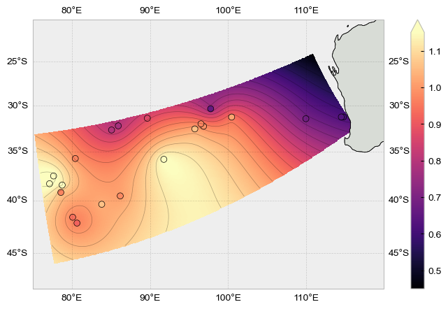

```python
### --- create new grid --- ###
min_x, min_y, max_x, max_y = ctd_gdf.total_bounds
XX_pk_ = np.linspace(min_x-(min_x*0.05), max_x+(max_x*0.01), 200) # Create a 100 by 100 grid
YY_pk_ = np.linspace(min_y-(min_y*0.05), max_y+(max_y*0.01), 200) # Horizontal and vertical cell counts should be the same
new_grid = [list(xy) for xy in zip(XX_pk_, YY_pk_)] # Create list of XY ctd pairs


### --- start with surface --- ###
m = 3 # bottle depth
j = 'd13C_permil_VPDB' # temperature

#r2, gridded_j = knn_ctd(m,j,ctd_gdf,new_grid)

da, original = krig_ctd(m,j,ctd_gdf,XX_pk_,YY_pk_,method='universal')


##### plot result
fig = plt.figure(figsize=(10, 5))
ax = fig.add_subplot(1, 1, 1, projection=ccrs.Mercator())
ax.coastlines()
ax.add_feature(cartopy.feature.LAND, zorder=0, facecolor='xkcd:light grey',edgecolor='black')
ctd_ = ctd_df[ctd_df['Depth_m']==3]
gl = ax.gridlines(draw_labels=True,linewidth=0.5, alpha=0.15, color='k',linestyle='--')
da.plot.pcolormesh(x='lon',y='lat',cmap='magma',ax=ax,transform=ccrs.PlateCarree(),vmin=0.45,vmax=1.15,zorder=-1)
hh = da.plot.contour(x='lon',y='lat',colors='k',linewidths=0.5,ax=ax,levels=20,alpha=0.3,transform=ccrs.PlateCarree())
sc = ax.scatter(ctd_['Long_E'],ctd_['Lat'],c=ctd_['d13C_permil_VPDB'],s=40,edgecolor='k',marker='o',transform=ccrs.PlateCarree(),cmap='magma',vmin=0.45,vmax=1.15,zorder=1,alpha=1)


ax.set_extent([75,120,-46,-20])

plt.savefig('krigged_13c.png',dpi=300)
```

## Try the function with Temperature

Although the aim of the notebook was to grid carbon isotope data, it will work with any variable in the dataframe. The code block below shows the result when interpolating ocean temperature instead.

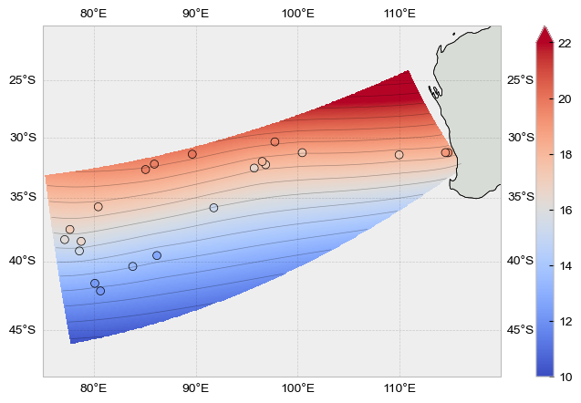

```python
### --- create new grid --- ###
min_x, min_y, max_x, max_y = ctd_gdf.total_bounds
XX_pk_ = np.linspace(min_x-(min_x*0.05), max_x+(max_x*0.01), 200) # Create a 100 by 100 grid
YY_pk_ = np.linspace(min_y-(min_y*0.05), max_y+(max_y*0.01), 200) # Horizontal and vertical cell counts should be the same
new_grid = [list(xy) for xy in zip(XX_pk_, YY_pk_)] # Create list of XY ctd pairs


### --- start with surface --- ###
m = 3 # bottle depth
j = 'T090C' # temperature

#r2, gridded_j = knn_ctd(m,j,ctd_gdf,new_grid)

da, original = krig_ctd(m,j,ctd_gdf,XX_pk_,YY_pk_,method='universal')


##### plot result
fig = plt.figure(figsize=(10, 5))
ax = fig.add_subplot(1, 1, 1, projection=ccrs.Mercator())
ax.coastlines()
ax.add_feature(cartopy.feature.LAND, zorder=0, facecolor='xkcd:light grey',edgecolor='black')
ctd_ = ctd_df[ctd_df['Depth_m']==3]
gl = ax.gridlines(draw_labels=True,linewidth=0.5, alpha=0.15, color='k',linestyle='--')

vmin = 10
vmax = 22
da.plot.pcolormesh(x='lon',y='lat',cmap='coolwarm',ax=ax,transform=ccrs.PlateCarree(),zorder=-1,vmin=vmin,vmax=vmax)
hh = da.plot.contour(x='lon',y='lat',colors='k',linewidths=0.5,ax=ax,levels=20,alpha=0.3,transform=ccrs.PlateCarree())
sc = ax.scatter(ctd_['Long_E'],ctd_['Lat'],c=ctd_[j],s=40,edgecolor='k',marker='o',transform=ccrs.PlateCarree(),cmap='coolwarm',zorder=1,alpha=1,vmin=vmin,vmax=vmax)


ax.set_extent([75,120,-46,-20])
```